# Tržišta pažnje u religijskim digitalnim medijima

Mapiranje hrvatskog katoličkog digitalnog prostora

Author

Šikić, Luka i Palić, Petra

Published

28. siječnja 2026.

# Sažetak

**Ključne riječi:** ekonomija pažnje, religijska komunikacija, digitalni mediji, Katolička crkva, Hrvatska

# 1 Uvod

Digitalna transformacija religijske komunikacije predstavlja jednu od najznačajnijih promjena u načinu na koji vjerske zajednice komuniciraju sa svojom publikom. Kako religijske organizacije sve više prenose svoje komunikacijske aktivnosti na digitalne platforme, ulaze na konkurentna tržišta pažnje gdje vidljivost nije zajamčena niti jednako distribuirana.

Herbert Simon slavno je primijetio da obilje informacija stvara oskudicu pažnje [@simon1971]. U suvremenim digitalnim okruženjima, ovaj uvid ima duboke implikacije za religijske organizacije koje su povijesno uživale privilegiran pristup svojim zajednicama kroz etablirane institucionalne kanale. Proliferacija digitalnih platformi demokratizirala je proizvodnju sadržaja istovremeno intenzivirajući natjecanje za pažnju publike.

Hrvatska predstavlja zanimljiv slučaj za ispitivanje religijske digitalne komunikacije. Kao zemlja u kojoj se približno 86 posto stanovništva izjašnjava kao rimokatolici, Katolička crkva održava značajnu kulturnu i institucionalnu prisutnost. Ipak, ovaj većinski status ne prevodi se automatski u digitalnu vidljivost. Hrvatski katolički digitalni prostor obuhvaća raznolike aktere: službene crkvene institucije, biskupijske komunikacijske urede, nezavisne katoličke medijske kuće, karizmatske pokrete obnove, pojedinačne klerike i laičke influencere koji vode pobožne stranice na društvenim mrežama.

Ova studija bavi se trima međusobno povezanim istraživačkim pitanjima. Prvo, kako je pažnja distribuirana među platformama i akterima u hrvatskom katoličkom digitalnom prostoru? Drugo, doživljavaju li institucionalni akteri sustavne nedostatke u privlačenju pažnje publike u usporedbi s grassroots i individualnim komunikatorima? Treće, kakvu ulogu igraju emocionalni sadržaj i vremenski ritmovi u alokaciji pažnje unutar religijskih digitalnih medija?

Za odgovor na ova pitanja analiziramo bazu podataka DigiKat koja obuhvaća 372.944 objava objavljenih između 01.01.2021. i 31.12.2024. kroz 8 kategorija platformi. Ukupno je obuhvaćeno 9.896 jedinstvenih izvora.

# 2 Teorijski okvir

## 2.1 Oskudica pažnje u digitalnim okruženjima

Paradigma ekonomije pažnje proizašla je iz prepoznavanja da tradicionalni ekonomski modeli neadekvatno zahvaćaju stvaranje i razmjenu vrijednosti u informacijski bogatim okruženjima. Simon je artikulirao temeljni uvid kada je primijetio da bogatstvo informacija stvara siromaštvo pažnje i potrebu za učinkovitom alokacijom te pažnje među preobiljem izvora informacija koji bi je mogli konzumirati [@simon1971].

Goldhaber je proširio ovaj okvir predlažući pažnju samu kao primarnu valutu digitalnih ekonomija [@goldhaber1997]. Za razliku od materijalnih dobara, pažnja se ne može proizvoditi, skladištiti ili transferirati. Svaki pojedinac posjeduje ograničenu dnevnu alokaciju pažnje za koju se različiti akteri natječu. Davenport i Beck formalizirali su upravljanje pažnjom kao organizacijski imperativ [@davenport2001].

Za religijske organizacije, okvir ekonomije pažnje otkriva fundamentalne tenzije između tradicionalnih komunikacijskih modela i digitalnih realnosti. Crkve su povijesno djelovale unutar okruženja privilegirane pažnje gdje su institucionalni autoritet i ukotvljenost u zajednici jamčili pristup publici. Digitalne platforme rastvaraju ove strukturalne prednosti, prisiljavajući religijske komunikatore da se natječu za pažnju na jednakoj razini sa sekularnim proizvođačima sadržaja.

## 2.2 Distribucije po zakonu potencije na tržištima pažnje

Konzistentan empirijski nalaz na digitalnim platformama jest da se pažnja distribuira prema zakonu potencije, a ne normalnim distribucijama [@barabasi1999]. U sustavima zakona potencije, mali broj aktera privlači nerazmjerno velike udjele ukupne pažnje dok velika većina ostaje relativno nevidljiva.

Rieder i suradnici dokumentirali su ekstremnu koncentraciju u svom velikom mapiranju YouTubea, otkrivši da gornjih 0,4 posto kanala čini 62 posto ukupnih pregleda [@rieder2020]. Webster je demonstrirao slične obrasce kroz raznolike medijske sustave [@webster2014]. Gini koeficijent pruža standardnu mjeru takve koncentracije, s vrijednostima koje se približavaju 1,0 indicirajući da gotovo sva pažnja teče prema maloj eliti proizvođača.

## 2.3 Učinci platformi na alokaciju pažnje

Digitalne platforme ne prenose samo sadržaj već aktivno oblikuju alokaciju pažnje kroz svoje tehničke arhitekture i algoritmičke sustave [@vandijck2018]. Svaka platforma ugrađuje posebne mogućnosti koje favoriziraju određene vrste sadržaja, komunikacijske stilove i kategorije aktera. Facebookov algoritam prioritizira sadržaj koji generira emocionalne reakcije i društveno dijeljenje. Instagram nagrađuje vizualnu estetiku. YouTubeov sustav preporuka usmjerava pažnju prema sadržaju koji maksimizira vrijeme gledanja.

## 2.4 Hipoteze

Iz teorije ekonomije pažnje izvodimo četiri provjerljive hipoteze o hrvatskom katoličkom digitalnom prostoru:

**Hipoteza 1 (Distribucija po zakonu potencije):** Pažnja u hrvatskom katoličkom digitalnom prostoru slijedi distribuciju po zakonu potencije, s angažmanom koncentriranim među malom elitom aktera. Očekujemo da log-log odnos između ranga i angažmana pokazuje jaku linearnost (R² > 0,90) i da Gini koeficijent prelazi 0,80.

**Hipoteza 2 (Omjeri koncentracije):** Gornjih 10 posto izvora privlači većinu ukupnog angažmana. Predviđamo CR10 koji prelazi 50 posto.

**Hipoteza 3 (Institucionalni jaz u pažnji):** Institucionalni akteri postižu niže stope angažmana od neinstitucionalnih aktera kao što su pojedinačni klerici, karizmatske zajednice i laički influenceri.

**Hipoteza 4 (Emocionalna diferencijacija):** Tipovi aktera pokazuju značajno različite emocionalne profile u odgovorima publike.

# 3 Podaci i metode

## 3.1 Baza podataka DigiKat

Ova studija koristi bazu podataka DigiKat, sveobuhvatnu zbirku hrvatskog katoličkog digitalnog sadržaja razvijenu kao dio trogodišnjeg istraživačkog projekta (2025. do 2027.). Baza podataka agregira javno dostupan digitalni sadržaj iz izvora identificiranih kao dio hrvatskog katoličkog medijskog ekosustava, obuhvaćajući službene crkvene komunikacije, nezavisne katoličke medijske kuće, župne i biskupijske kanale, publikacije redovničkih zajednica, stranice karizmatskih zajednica i glasove pojedinačnih klerika.

## 3.2 Prikupljanje podataka

Prikupljanje podataka koristilo je više komplementarnih metoda prilagođenih tehničkim ograničenjima specifičnim za platforme. Web sadržaj prikupljen je automatiziranim scrapingom identificiranih katoličkih portala. Facebook i Instagram podaci dobiveni su kroz CrowdTangle. YouTube podaci prikupljeni su putem YouTube Data API-ja. Postupci kontrole kvalitete adresirali su uobičajene izazove u velikom prikupljanju digitalnih podataka.

## 3.3 Klasifikacija aktera

Za analizu distribucije pažnje među različitim tipovima katoličkih komunikatora, razvili smo hijerarhijski sustav klasifikacije koji dodjeljuje svaki izvor jednoj od deset kategorija aktera. Rezultirajućih deset kategorija obuhvaća: službene institucije, biskupije i župe, nezavisni mediji, redovničke zajednice, karizmatske zajednice, pojedinačni svećenici, mladežne organizacije, akademske institucije, laički influenceri i ostalo.

## 3.4 Analitički pristup

Analiza se odvija kroz četiri komplementarne dimenzije. Za procjenu tržišne strukture i koncentracije koristimo Gini koeficijent, Lorenzove krivulje i omjere koncentracije. Za ispitivanje institucionalnog jaza koristimo Wilcoxonov test sume rangova. Za analizu emocionalnog privlačenja pažnje ispitujemo distribucije Facebook reakcija koristeći Kruskal-Wallisove testove. Za vremensku dinamiku mapiramo aktivnost objavljivanja na katolički liturgijski kalendar.

# 4 Rezultati

## 4.1 Tržišna struktura i koncentracija

Table 1: Distribucija objava i angažmana po platformama

Distribucija objava i angažmana po platformama

| Platforma | Objave | Interakcije | Izvori | Prosj. int. | Volumen % | Angažman % | Učinkovitost |
| --- | --- | --- | --- | --- | --- | --- | --- |
| web | 295.860 | 32.256.123 | 2.738 | 109.0 | 79.3% | 79.1% | 1.00 |
| youtube | 38.267 | 4.946.542 | 2.838 | 133.1 | 10.3% | 12.1% | 1.18 |
| facebook | 24.269 | 3.268.408 | 1.510 | 134.7 | 6.5% | 8.0% | 1.23 |
| forum | 4.361 | 0 | 7 | NaN | 1.2% | 0.0% | 0.00 |
| reddit | 3.857 | 0 | 1.319 | NaN | 1.0% | 0.0% | 0.00 |
| twitter | 3.211 | 28.532 | 1.536 | 8.9 | 0.9% | 0.1% | 0.08 |
| comment | 1.989 | 0 | 23 | NaN | 0.5% | 0.0% | 0.00 |
| instagram | 1.130 | 299.344 | 54 | 264.9 | 0.3% | 0.7% | 2.42 |

Indeks učinkovitosti, izračunat kao omjer udjela angažmana i udjela volumena, otkriva značajnu varijaciju u učinkovitosti platformi. Vrijednosti iznad 1,0 indiciraju platforme koje generiraju više angažmana nego što bi njihov volumen sadržaja predviđao.

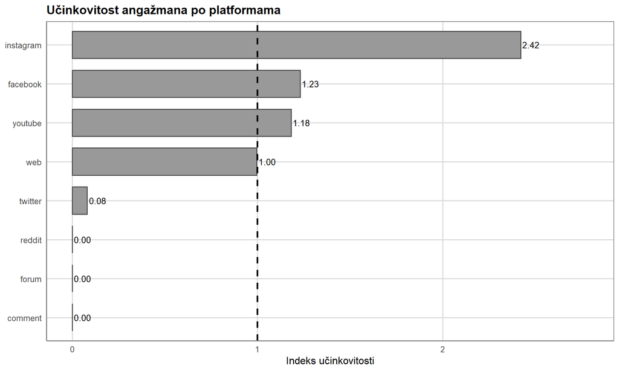

Figure 1: Učinkovitost angažmana po platformama. Indeks učinkovitosti predstavlja omjer udjela angažmana i udjela volumena, s vrijednostima iznad 1,0 (isprekidana linija) koje indiciraju nadprosječne rezultate.

### 4.1.1 Mjere koncentracije

Mjere koncentracije testiraju Hipoteze 1 i 2. Gini koeficijent iznosi 0.980, što indicira ekstremnu nejednakost u distribuciji pažnje. Za usporedbu, ovo znatno premašuje tipične mjere dohodovne nejednakosti u većini razvijenih zemalja. Regresija zakona potencije daje R² = 0.912, snažno podržavajući Hipotezu 1 o distribuciji po zakonu potencije.

Omjeri koncentracije pokazuju da vodećih 10 izvora privlači 44.6% ukupnog angažmana, vodećih 20 izvora privlači 56.5%, a gornjih 10 posto svih izvora (990 izvora) privlači čak 98.3% ukupnog angažmana.

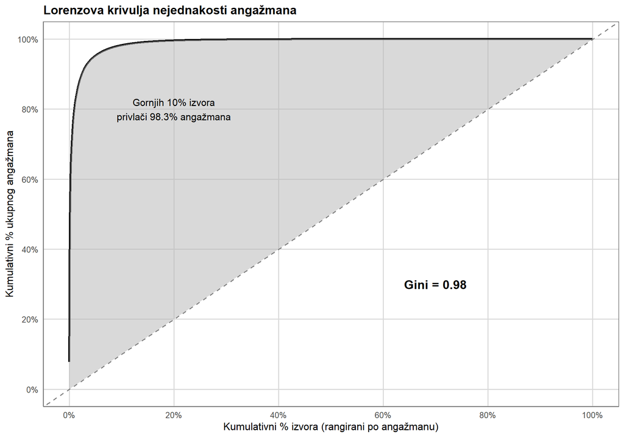

Figure 2: Lorenzova krivulja nejednakosti angažmana. Osjenčano područje između krivulje i dijagonale jednakosti predstavlja stupanj koncentracije.

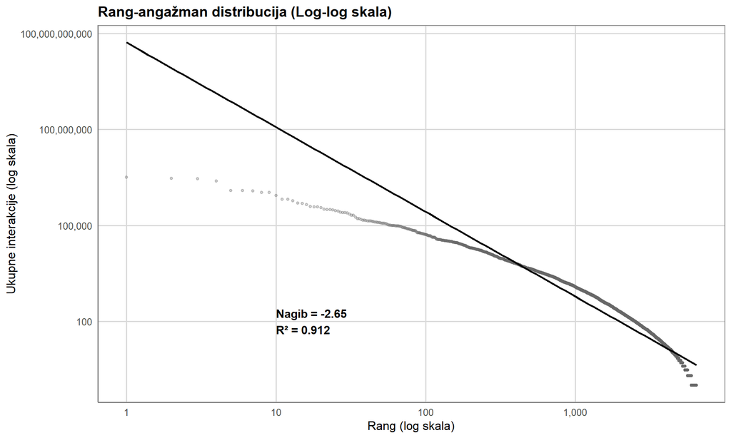

## 4.2 Stratifikacija aktera i institucionalni jaz

Table 2: Sadržaj i angažman po tipu aktera

Sadržaj i angažman po tipu aktera

| Tip aktera | Izvori | Objave | Interakcije | Prosj. int. | Objave % | Angažman % | Učinkovitost |
| --- | --- | --- | --- | --- | --- | --- | --- |
| Ostalo | 9.396 | 275.765 | 30.383.155 | 114.8 | 73.9% | 74.5% | 1.01 |
| Nezavisni mediji | 15 | 20.113 | 4.971.266 | 247.2 | 5.4% | 12.2% | 2.26 |
| Službene institucije | 142 | 49.339 | 3.141.703 | 63.7 | 13.2% | 7.7% | 0.58 |
| Laički influenceri | 175 | 13.500 | 1.726.046 | 129.9 | 3.6% | 4.2% | 1.17 |
| Biskupije i župe | 89 | 11.278 | 453.441 | 40.2 | 3.0% | 1.1% | 0.37 |
| Karizmatske zajednice | 13 | 551 | 68.683 | 130.3 | 0.1% | 0.2% | 1.14 |
| Redovničke zajednice | 36 | 1.678 | 37.113 | 22.4 | 0.4% | 0.1% | 0.20 |
| Akademske institucije | 12 | 473 | 8.842 | 18.7 | 0.1% | 0.0% | 0.17 |
| Mladežne organizacije | 7 | 111 | 4.606 | 41.5 | 0.0% | 0.0% | 0.38 |
| Pojedinačni svećenici | 15 | 136 | 4.094 | 30.1 | 0.0% | 0.0% | 0.28 |

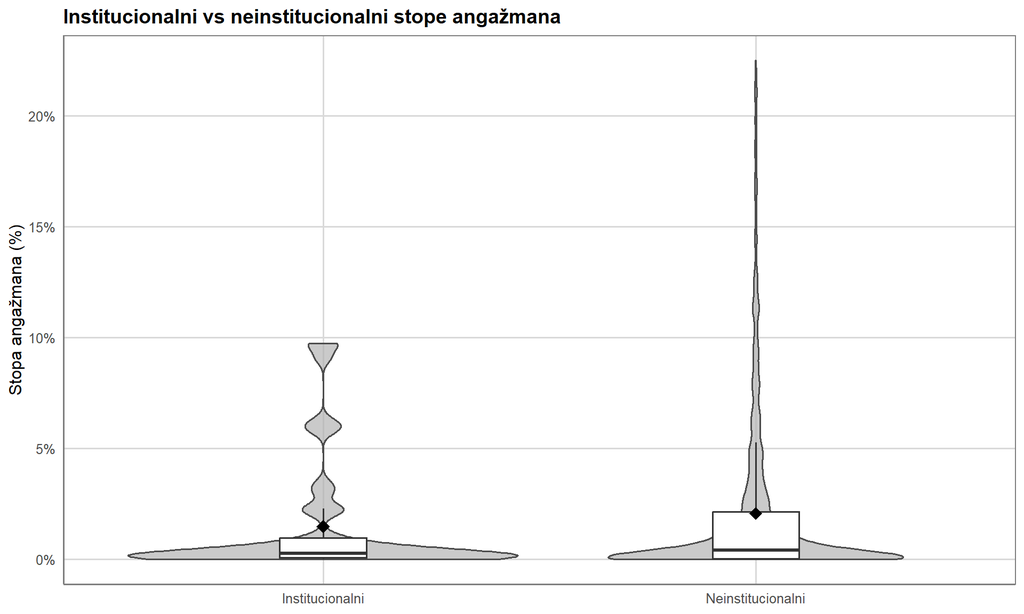

Figure 4: Distribucije stopa angažmana uspoređujući institucionalne i neinstitucionalne aktere. Crni rombovi označavaju prosjeke.

## 4.3 Emocionalno privlačenje pažnje

Table 3: Emocionalni profili po tipu aktera (prosječni udio reakcija)

Emocionalni profili po tipu aktera (prosječni udio reakcija)

| Tip aktera | Objave | LOVE | WOW | HAHA | SAD | ANGRY |
| --- | --- | --- | --- | --- | --- | --- |
| Akademske institucije | 1 | 100.0% | 0.0% | 0.0% | 0.0% | 0.0% |
| Laički influenceri | 22 | 95.3% | 0.0% | 0.2% | 4.5% | 0.0% |
| Biskupije i župe | 8 | 75.1% | 0.0% | 0.0% | 24.9% | 0.0% |
| Nezavisni mediji | 32 | 62.8% | 2.0% | 9.2% | 20.5% | 5.5% |
| Ostalo | 136 | 43.2% | 2.7% | 25.9% | 12.3% | 15.9% |
| Službene institucije | 2 | 0.0% | 50.0% | 16.7% | 0.0% | 33.3% |

Udjeli LOVE i ANGRY reakcija značajno se razlikuju među tipovima aktera (Kruskal-Wallis χ² = 31 za LOVE, *p* < 0,001; χ² = 26.3 za ANGRY, *p* < 0,001), čime je potvrđena Hipoteza 4 o emocionalnoj diferencijaciji.

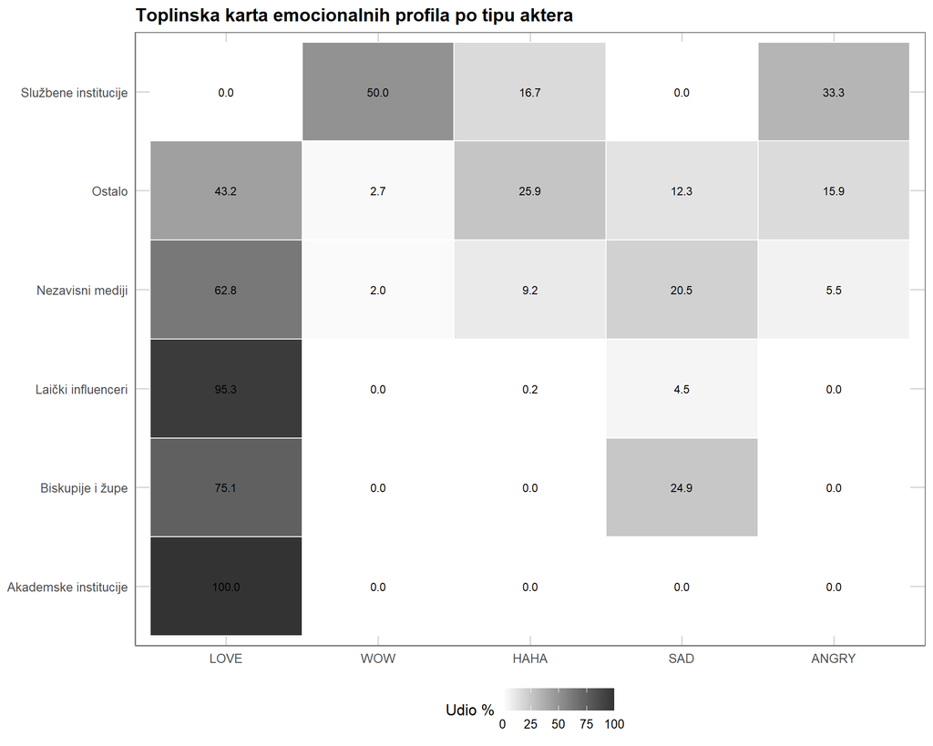

Figure 5: Toplinska karta emocionalnih profila po tipu aktera. Tamnije boje indiciraju veće udjele.

## 4.4 Vremenska dinamika

Table 4: Aktivnost po liturgijskim vremenima

Aktivnost po liturgijskim vremenima

| Vrijeme | Objave | Interakcije | Prosj. int. | Dani | Objava/dan | Int./dan | Učinak vs bazna |
| --- | --- | --- | --- | --- | --- | --- | --- |
| Došašće | 38.711 | 3.308.225 | 87.1 | 99 | 391 | 33416 | +32.6% |
| Božić | 24.227 | 3.295.516 | 141.6 | 73 | 332 | 45144 | +12.5% |
| Korizma | 34.746 | 4.020.204 | 118.5 | 138 | 252 | 29132 | -14.6% |
| Uskrs | 33.741 | 4.238.255 | 130.0 | 141 | 239 | 30059 | -18.9% |
| Vrijeme kroz godinu | 241.519 | 25.936.749 | 110.9 | 819 | 295 | 31669 | +0.0% |

Jednouzorački t-test potvrđuje da blagdani generiraju značajno povišenu aktivnost objavljivanja u usporedbi s baznom linijom (*t* = 4.9, df = 34, *p* < 0,001), s prosječnom veličinom učinka od 32.0% iznad bazne linije.

## 4.5 Sažetak testiranja hipoteza

Table 5: Sažetak rezultata testiranja hipoteza

Sažetak rezultata testiranja hipoteza

[output not shown]

# 5 Rasprava

Nalazi otkrivaju da hrvatski katolički digitalni prostor pokazuje nejednakost pažnje usporedivu s ili veću od obrazaca dokumentiranih u komercijalnim medijskim ekosustavima. Gini koeficijent od 0.980 znatno premašuje pragove tipično povezane s visokom koncentracijom. Ovi rezultati potvrđuju Hipotezu 1 i usklađeni su s teorijskim predikcijama o dinamici pobjednik uzima sve u digitalnim okruženjima.

# 6 Zaključak

Ova studija pruža prvo sustavno mapiranje nacionalnog katoličkog digitalnog medijskog ekosustava, analizirajući više od 372.944 objava kroz više platformi radi ispitivanja distribucije pažnje, stratifikacije aktera, emocionalne dinamike i vremenskih obrazaca u hrvatskoj katoličkoj digitalnoj komunikaciji.

Za praktičare katoličke komunikacije, ovi nalazi nude empirijski utemeljenu orijentaciju prema pejzažu pažnje koji nastanjuju. Razumijevanje strukturalnih ograničenja i mogućnosti može informirati realističnija očekivanja i učinkovitije strategije za religijsku komunikaciju u digitalnim okruženjima gdje pažnja ostaje najoskudniji i najosporavaniji resurs.